# Permit Prediction in Philadelphia, PA

Jamie Song, Gabriel Hernandez

2023-12-16

Note: To view our Pechakucha presentation focusing more on the use case for this model, [please see this YouTube video.](https://urldefense.com/v3/__https://www.youtube.com/watch?v=aBaukkmGINk__;!!IBzWLUs!XAilxDF0-SUZCSWW5L-NhiIWCHcOGS9fbLyd8cfpm19hpeZWIQqHUtAhW-kNL9ZaetQWk9rlKV82YcsgVF8555Do-A$)

# 1 Introduction

As we move along corridors and spaces in a city, we can tell where there is new development going on and where there is not. This is because the built environment is a symbol for processes of change. Some of these processes are related to the systems of power that govern a given site at a particular point in time. Market forces at the time of construction impart meaning to a site, which can be as simple as – at this point in time, someone wanted to build a new structure and they applied for a permit.

The housing market of a city ranges from neighborhood to neighborhood, so when a particular neighborhood has a high amount of permits – meaning that people are either building or tearing down a structure – we can infer that it is an area with high development activity. We decided to analyze the pattern of permit applications for the City of Philadelphia to identify where there are development “hotspots.” Hotspots are locations where there are statistically significant clusters of high permit counts. We also wanted to explore the predictive power of two approaches to identifying future hotspots in the city.

We were motivated to perform this analysis because of its implication for activism and the potential of the analysis to confirm the development that we see around the city. In meetings with the Director of Development at Nehemiah HDFC, a NYC-based affordable development company, we learned that this type of analysis can provide a basis for considering where to target neighborhood-wide rezoning campaigns. Neighborhood-wide rezonings can make it easier to increase the supply of housing with the stroke of a pen, and they can protect the roots of long-term residents and businesses in the community. Thus, if our model is accurate, then it gives lead organizers more power to carry out actions on behalf of a gentrifying community. We seek to create a model that identifies communities experiencing high concentrations of development and that uncovers where there is latent potential for more permit applications.

We set up two models, a long-term and a short-term. The purpose was to compare their performance and to know if a few years worth of permit data would be enough to accurately predict permit hotspots. The success of the short-term model would incentivize communities to advocate for a properly formatted permit database. With development areas identified it will be easier to conduct neighborhood-wide and other small scale rezoning initiatives.

Our approach to the model creation process starts with filtering the permits dataset to select the ones that we believe are related to development. We will then use geocomputation techniques to develop indicators that can predict the count of permits per unit of analysis. We will then explore the correlation of our features and create a regression model to cross-validate by neighborhood. Lastly, we will predict future permit counts and identify hotspots using local Moran’s I cluster analysis. We will conduct the same procedure for two different time frames and compare their performance to determine at which scale we can best predict significant hotspots of permits.

# 2 Long-Term Model Methods and Results

We will begin our analysis with what we call our long-term model. This version of our permit hotspot prediction model will take the total permit counts for the 2009-2018 period and predict the 2019 permit counts across the City of Philadelphia. The short-term model will use a shorter time period of permits, the 2021-2022 period to predict for permits in 2023. We will otherwise use the same engineered features in each model, which will be related to the relationship between a neighborhood’s position and socio-demographic changes across the City of Philadelphia between 2013-2019.

Again, the purpose here is to investigate how accurately we can predict permit counts, and then whether we need 2 years of data or 10 to identify permit hotspots for a following year.

## 2.1 Data Sources

Below, we load data to build our permit prediction model. The datasets and corresponding sources are as follows:

- Geographies
  - Neighborhoods: Azavea
  - Boundaries: City of Philadelphia
- Dependent Variable
  - Permits: City of Philadelphia
- Predictor Variables
  - Transit stations: City of Philadelphia
  - Demographic variables at block group level: US Census Bureau

In selecting permits, we inherently introduce bias into our analysis. There is a wide range of “type of work” values in the permit data but we wanted to focus on those that added new structures, demolished others, added value to the structure, demolished the interior, or other techniques used to make a development projects work. These are just a few examples and we point out others below. We had to interpret the overlap between the type of work designation whether it came from the department of buildings or the zoning office for the same place. Should only one department be used? We took the multiple observations as an indicator of the willingness of developers to jump over multi-tiered bureaucratic barriers to development.

We used a query that filtered for any of the following permit type-related terms and more (see code):

- FULL = Building permit - Demolition related
- INTERI = Interior demolition
- ADD = Zoning permit, add things to the building from structures to appliances/tech such as antennas
- SHELL - Building Permit - Construction of structure before separate permits for occupancy and fitout are done
- ENTIRE = Building Permit - New Construction related
- FRAME - Building Permit - Steel structures for building construction
- NEWCON = Zoning permit related - New construction
- COMDEM = Zoning permit - Complete demolition
- FITOUT = Tenants building out unit provided by developer

For demographic variables, we chose to import 2013 and 2019 block group level data. We wanted to work into our long-term model the relationship between neighborhood changes in demographics with the development intensity. We were limited to calculating percent changes between those years because block group level data was not available prior to 2013, and block group geometries changed after 2019 because of 2020 Census redistricting. The resulting indicators that we worked into our model for this subset of years are:

- Change in White proportion of population
- Change in vacancy rate
- Change in ICE score (economic only)
- Percent change in median home value

> A Note on ICE:

The ICE metric was developed by social science and epidemiology researchers to capture “extremes of privilege and deprivation” as well as measure both economic and racial segregation. It is calculated using the following formula:

$$ICE=\frac{(A−P)}{T}$$

Where A represents the number of households belonging to the privileged extreme, while P is the number of households who belong to the deprived extreme in a given area. T is the total number of households in that area.

ICE can take any value between -1 and 1; a value of 1 indicates that all residents are in the “privileged” group, and a value of −1 indicates that all residents are in the most “deprived” group. For this model, the privileged group is defined as households with incomes over 100,000 USD, and the deprived group is defined as households with incomes below 25,000 USD.

```r
user.dir = "C:/Users/songj/OneDrive/Documents/GitHub/musa-5080/PPA_FINAL"
user2.dir = "E:/MUSA/Github/musa-5080-jsong/PPA_FINAL"
user3.dir = "C:/Users/Gabriel/Documents/GitHub/musa-5080-jsong/PPA_FINAL"
data.dir = "C:/Users/songj/OneDrive/Documents/MUSA/musa 5080/local_data_final"
#setwd(user.dir) #change as needed

  #bring in permits data, mutate time variables from dates

city_permits1623 <- file.path(data.dir,"Data/permits_1623") #NOTE: you have to download this shapefile to your user directory in order to run this code properly
city_permits0715 <- file.path(data.dir,"Data/permits_0715")

cp_1623.sf <- st_read(city_permits1623)
cp_0715.sf <- st_read(city_permits0715)

  #begin wrangling of Permit data 0715

permdesc1623 <-unique(cp_1623.sf$permitdesc)
typework1623 <-unique(cp_1623.sf$typeofwork)
permdesc0715 <-unique(cp_0715.sf$permitdesc)
typework0715 <-unique(cp_0715.sf$typeofwork)

  #I analyzed this to conclude the following cleanup that focuses on development
  # the types are the same for both 2007 and 2016 data. A bias is that 1016 might have more types of work that dont feature in the 2007 types of work
  # permi type is not a good indicator because its subsets into many different things, many of which are related to development per say

chosen_permittypes <- c('FULL', 'INTERI', "ADD", 'SHELL', 'ENTIRE', 'FRAME', 'NEWCON', 'COMDEM', 'FITOUT',
                        'NEW CONSTRUCTION')

cp_0915.sf <- cp_0715.sf %>%
  st_transform(crs = crs) %>%
  dplyr::filter(permitissu >= as.POSIXct("2009-01-01"),
                str_detect(typeofwork, paste(chosen_permittypes, collapse = "|")))

cp_1623.sf <- cp_1623.sf %>%
  st_transform(crs=crs) %>%
  dplyr::filter(str_detect(typeofwork, paste(chosen_permittypes, collapse = "|")))

# combine all points from both datasets
cp_0923.sf <- rbind(cp_0915.sf, cp_1623.sf)
cp_0923.sf <- cp_0923.sf[!st_is_empty(cp_0923.sf), ]

# add time variables and fixed effects
cp_0923.sf <- cp_0923.sf %>%
  mutate(week = week(permitissu), #week # of year
         month = month(permitissu), #month of year
         year = as.numeric(substr(permitissu,1,4)),
         year.num = year-2008,
         week.FE = week * year.num,
         month.FE = month * year.num)

# Make model and test (2019) sets

cpfinal_19.sf <- cp_0923.sf %>%
  dplyr::filter(year==2019)

cpfinal_0923.sf <- cp_0923.sf %>%
  dplyr::filter(year<2019)

cpfinal_2122.sf <- cp_0923.sf %>%
  dplyr::filter(year==2021 | year==2022)

## 2023 data so far
cpfinal_23.sf <- cp_0923.sf %>%
  dplyr::filter(year==2023)

# CENSUS DATA

##load variables
acs_vars = c("B02001_001E",
"B02001_002E",
"B19013_001E",
"B25058_001E",
"B17021_001E","B17021_002E", #poverty
"B05012_003E",
"B25001_001E",#housing units
"B25002_003E",
"B25002_001E",
"B25071_001E",
"B19101_001E", #ICE-all households of all incomes
"B19101_002E","B19101_003E","B19101_004E","B19101_005E", #ICE - <25k
"B19101_014E","B19101_015E","B19101_016E","B19101_017E", #ICE - >100k
"B25077_001E")

#load philly block groups from ACS, 2019 and 2013
phlblockgroups.sf.19 <-
  get_acs(geography = "block group",
          variables = acs_vars,
          year=2019, state="PA", county="Philadelphia",
          geometry=TRUE, output="wide") %>%
  st_transform(crs=crs)%>%
  rename(TotalPop19 = B02001_001E,
         Whites19 = B02001_002E,
         MedHHInc19 = B19013_001E,
         MedRent19 = B25058_001E,
         HousingUnits19 = B25001_001E,
         TotalHHs19 = B25002_001E,
         VacantHHs19 = B25002_003E,
         ICE_T19 = B19101_001E,
         MedHVal19 = B25077_001E) %>%
  dplyr::filter(TotalPop19 > 0) %>%
  mutate(pctWhite19 = ifelse(TotalPop19 > 0, Whites19 / TotalPop19,0),
         pctPoverty19 = ifelse(TotalPop19 > 0, B17021_002E / B17021_001E, 0),
         pctVacant19 = ifelse(TotalHHs19 > 0, VacantHHs19 / TotalHHs19, 0),
         avgHHsize19 = ifelse(TotalHHs19 > 0, TotalPop19 / TotalHHs19, 0),
         ICE_A19 = ifelse(TotalHHs19 > 0,
                      (B19101_014E+B19101_015E+B19101_016E+B19101_017E), 0),
         ICE_P19 = ifelse(TotalHHs19 > 0,
                      (B19101_002E+B19101_003E+B19101_004E+B19101_005E), 0),
         ICE_bg19 = (ICE_A19 - ICE_P19)/ICE_T19,) %>%
  dplyr::select(-NAME, -starts_with("B"))

phlblockgroups.sf.13 <-
  get_acs(geography = "block group",
          variables = acs_vars,
          year=2013, state="PA", county="Philadelphia",
          geometry=TRUE, output="wide") %>%
  st_transform(crs=crs)%>%
  rename(TotalPop13 = B02001_001E,
         Whites13 = B02001_002E,
         MedHHInc13 = B19013_001E,
         MedRent13 = B25058_001E,
         HousingUnits13 = B25001_001E,
         TotalHHs13 = B25002_001E,
         VacantHHs13 = B25002_003E,
         ICE_T13 = B19101_001E,
         MedHVal13 = B25077_001E) %>%
  dplyr::filter(TotalPop13 > 0) %>%
  mutate(pctWhite13 = ifelse(TotalPop13 > 0, Whites13 / TotalPop13,0),
         pctPoverty13 = ifelse(TotalPop13 > 0, B17021_002E / B17021_001E, 0),
         pctVacant13 = ifelse(TotalHHs13 > 0, VacantHHs13 / TotalHHs13, 0),
         avgHHsize13 = ifelse(TotalHHs13 > 0, TotalPop13 / TotalHHs13, 0),
         ICE_A13 = ifelse(TotalHHs13 > 0,
                      (B19101_014E+B19101_015E+B19101_016E+B19101_017E), 0),
         ICE_P13 = ifelse(TotalHHs13 > 0,
                      (B19101_002E+B19101_003E+B19101_004E+B19101_005E), 0),
         ICE_bg13 = (ICE_A13 - ICE_P13)/ICE_T13) %>%
  dplyr::select(-NAME, -starts_with("B")) %>%
  st_drop_geometry()

phlblockgroups.sf <- left_join(phlblockgroups.sf.19, phlblockgroups.sf.13, by = "GEOID") %>%
                     mutate(pctchangeWhite1319 = pctWhite19 - pctWhite13,
                            pctchangePoverty1319 = pctPoverty19 - pctPoverty13,
                            pctchangeVacant1319 = pctVacant19 - pctVacant13,
                            changeICE1319 = ICE_bg19 - ICE_bg13,
                            pctchangeHUnits1319 = (HousingUnits19 - HousingUnits13) / HousingUnits13,
                            pctchangeHVal1319 = (MedHVal19 - MedHVal13) / MedHVal13
                            ) %>%
                     st_as_sf() %>%
                     st_transform(crs=crs) %>%
                     mutate_all(~replace_na(., 0)) #impute 0 for missing values

# phlblockgroups.sf <- phlblockgroups.sf[!st_is_empty(phlblockgroups.sf$geometry), ] #no longer needed

## Philly neighborhoods and philly boundary
nhoods <- st_read("https://github.com/azavea/geo-data/raw/master/Neighborhoods_Philadelphia/Neighborhoods_Philadelphia.geojson") %>% st_transform(crs=crs)

boundary <- st_read("http://data.phl.opendata.arcgis.com/datasets/063f5f85ef17468ebfebc1d2498b7daf_0.geojson")%>% st_transform(crs=crs)

# TOD zone based on septa stations
el <- st_read("https://opendata.arcgis.com/datasets/8c6e2575c8ad46eb887e6bb35825e1a6_0.geojson")
bsl <- st_read("https://opendata.arcgis.com/datasets/2e9037fd5bef406488ffe5bb67d21312_0.geojson")

septaStops <-
  rbind(
     el %>%
      mutate(Line = "MFL") %>%
      dplyr::select(Station, Line),
     bsl %>%
      mutate(Line = "BSL") %>%
      dplyr::select(Station, Line)) %>%
  st_transform(crs=crs)

buffer <- st_union(st_buffer(septaStops, 2640))

## distance to commercial corridors - from midterm
corridors_path <- "https://opendata.arcgis.com/datasets/f43e5f92d34e41249e7a11f269792d11_0.geojson"
corridors <- st_read(corridors_path, quiet= TRUE) %>% st_transform(crs = crs)

nearest_fts <- sf::st_nearest_feature(cpfinal_0923.sf, corridors)

## convert to rsgeo geometries
k <- rsgeo::as_rsgeo(cpfinal_0923.sf)
j <- rsgeo::as_rsgeo(corridors)
```

## 2.2 Point Pattern Analysis

Now that we have the data set up, we can begin to explore it. Below, we visualize the distribution of permits across Philadelphia to paint a preliminary idea about where there may be hotspots.

### 2.2.1 Fishnet of Filtered Permit Types

At a glance, we observe higher concentrations of permits in South Philadelphia around Point Breeze, as well as North Philadelphia in the Brewerytown and Fishtown sections.

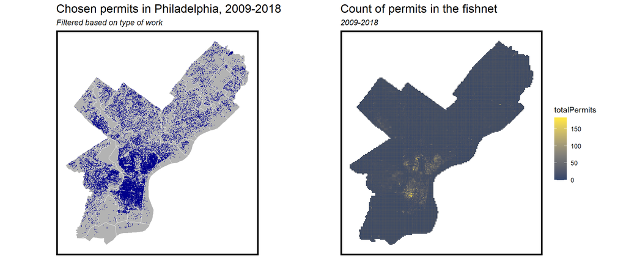

```r
fishnet <-
  st_make_grid(boundary, cellsize = 500, square=TRUE) %>%
  .[boundary]%>%
  st_sf() %>%
  mutate(uniqueID = rownames(.))

permit_net <-
  dplyr::select(cpfinal_0923.sf) %>%
  mutate(totalPermits = 1) %>%
  aggregate(., fishnet, sum) %>%
  mutate(totalPermits = replace_na(totalPermits, 0),
         uniqueID = rownames(.),
         cvID = sample(round(nrow(fishnet) / 24),
                       size=nrow(fishnet), replace = TRUE),
         range = "2009-2018")

grid.arrange(nrow=1,
ggplot() +
  geom_sf(data = nhoods, color = "white", fill = "gray70") +
  geom_sf(data = cpfinal_0923.sf,
          color = "blue4",
          size = 0.05) +
  labs(title = "Chosen permits in Philadelphia, 2009-2018",
       subtitle = "Filtered based on type of work") +
  mapTheme()
,
ggplot() +
  geom_sf(data = permit_net,
          aes(fill = totalPermits)) +
  scale_fill_viridis(option="cividis",
                     begin=0.2,
                     end=1)+
  labs(title = "Count of permits in the fishnet",
       subtitle = "2009-2018") +
  mapTheme()
)
```

### 2.2.2 Histogram of Permit Counts by Fishnet Cell

The following histogram shows the distribution of permit counts by fishnet cell. The distribution is highly skewed right with a concentration towards lower values. It approximates a Poisson distribution, suggesting that for most of the city there are very low counts of “development” related permit types. This highlights that a property of development itself (pun intended) is that it is opportunistic, and that it does not manifest equally across the city. What determines an “opportunity” and how it affects our observed permit counts is beyond the scope of this project.

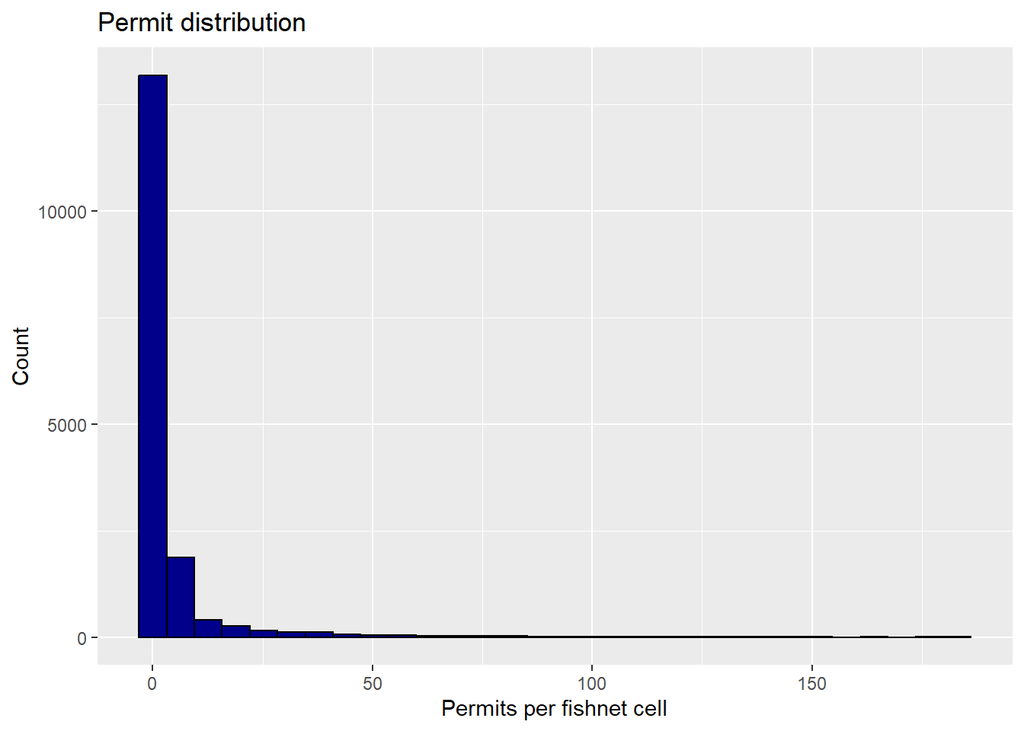

```r
ggplot(permit_net) +
  geom_histogram(bins = 30, colour="black", fill = "blue4") +
  aes(totalPermits) +
    labs(title="Permit distribution",
         x="Permits per fishnet cell", y="Count")
```

### 2.2.3 Distribution of each unique type of work permit

This code shows the distribution of each type of permit that we defined as development – related to our observed counts dependent variable. Again, we will note that in 2020, the City of Philadelphia began defining each permit type differently and introduced new possible values. Our original filter would have omitted post-2020 observations in our observed permit counts. There appears to be redundancy in types, but it is a reflection of the new definitions used for the variable ‘typeofwork’. We believe the most interesting of these maps is the ‘Fitout’ type because it is a very specific venture with low spread across Philadelphia. It would be an interesting process to investigate further: why is there a concentration of fitouts in the clustered area?

```r
# Visualizing type of permit geographically
cpfinal_0923.sf %>%
  dplyr::filter(typeofwork != "FRAME" & typeofwork != "SHELL") %>%
ggplot() +
  geom_sf(data = nhoods, color = "transparent", fill = "gray80") +
  geom_sf(aes(color = typeofwork), size = 0.05) +  # Specify color aesthetic
  facet_wrap(~typeofwork, nrow=2) +
  mapTheme()
```

[output not shown]

```r
 #remove legend
```

### 2.2.4 Local Moran’s I Hotspot Engineered Features

To analyze the relationship between our permits point data and the changes observed in the block group level ACS data between 2013-2019, we used local Moran’s I to our advantage. For each variable that we analyzed the distribution of percent changes, we used local Moran’s I to identify its statistically significant hotspots across Philadelphia. We then calculated the distance of each neighborhood to the nearest hotspot for each indicator’s hotspot and added it to our model. We believe that these indicators serve as a part of the “exposure” that affects the observed total “development” permit counts across Philadelphia.

The indicators created in this process capture changes that took place between 2013-2019 and that we think are related to development, such as the percent changes in vacant units, poverty rates, white population as a function of historically disproportionate access to capital, and ICE scores. Understanding the limitations of arguing for using the same exposure period for both models, we recall from in-class guidance that what matters is that the model is powerful and generalizable, not so much that the inputs are theoretically coherent. Given our results and the previous discussion about how we consider the indicators relevant to development, we feel justified in maintaining them in both models.

#### 2.2.4.1 Local Moran’s I Feature Engineering - Existing Permit Hotspots & Socio-Demographic Variables

The following graphics follow the creation of permit hotspots. The local Moran’s I value at each fishnet cell indicates the extent of significant spatial clustering of permit counts around that cell. P-values are calculated using Monte Carlo simulations and represent the probability of obtaining the same spatial distribution of permit counts if permits are distributed randomly. Therefore, very small p-values indicate hotspots, which we identified at a $\alpha = 0.000001$ significance level.

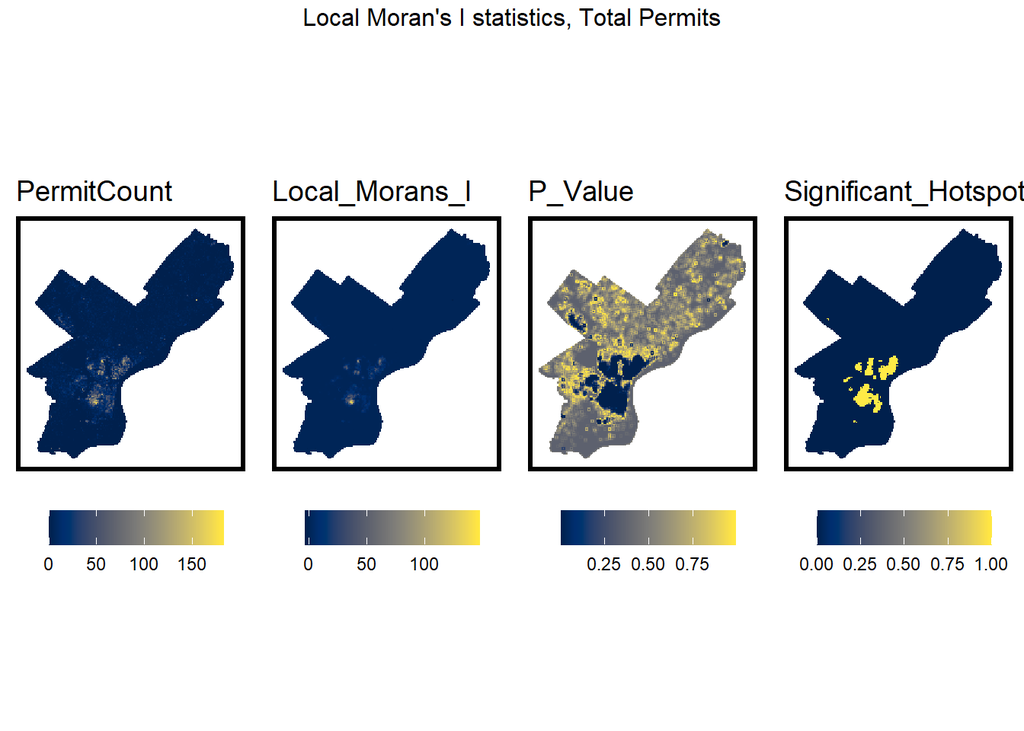

```r
final_net.nb <- poly2nb(as_Spatial(final_net), queen=TRUE)
final_net.weights <- nb2listw(final_net.nb, style="W", zero.policy=TRUE)

local_morans <- localmoran(final_net$totalPermits,
                           final_net.weights,
                           zero.policy=TRUE) %>%
                as.data.frame()

final_net.localMorans.Permit <-
  cbind(local_morans, as.data.frame(final_net)) %>%
  st_sf() %>%
  dplyr::select(PermitCount = totalPermits,
                Local_Morans_I = Ii,
                P_Value = `Pr(z != E(Ii))`) %>%
  mutate(Significant_Hotspots = ifelse(P_Value <= 0.000001, 1, 0)) %>%
  gather(Variable, Value, -geometry)

vars <- unique(final_net.localMorans.Permit$Variable)
varList <- list()

for(i in vars){
  varList[[i]] <-
    ggplot() +
      geom_sf(data = nhoods, color = "transparent", fill = "gray80") +
      geom_sf(data = filter(final_net.localMorans.Permit, Variable == i),
              aes(fill = Value), colour=NA) +
      scale_fill_viridis(option = "E", name="") +
      labs(title=i) +
      mapTheme(title_size = 14) + theme(legend.position="bottom")}

do.call(grid.arrange,c(varList, ncol = 4, top = "Local Moran's I statistics, Total Permits"))
```

To address challenges in using block group level data in fishnet cell level analyses, particularly incongruence between block group and fishnet cell geometries, we generated hotspots for variables related to socio-demographic changes using local Moran’s I at a $\alpha = 0.01$ significance level. We then calculated the distance from each fishnet cell to its closest hotspot. We also use the previously generated local Moran’s I hotspots of permits at a $\alpha = 0.000001$ significance level, then engineered an indicator that equaled the distance from an individual fishnet cell to its nearest permit hotspot.

We believe that including these relationships between places and hotspots captures spatial relationships that influence where there are opportunities for development in the first place. As mentioned earlier, development is an opportunistic undertaking. As latent opportunities become viable, development finds itself in new places, and the pack of speculative developers follow suit.

Understanding how hotspots are created in the first place could be very important to the work of cities, potentially leading to neighborhood wide rezonings that are programmed in part to entice development. This path of inquiry can answer important questions such as: how do we bring development to areas where there isn’t currently? And what neighborhood characteristics are leading to more investments in hotspot areas?

```r
phlblockgroups.nb <- poly2nb(as_Spatial(phlblockgroups.sf), queen=TRUE)
phlblockgroups.weights <- nb2listw(phlblockgroups.nb, style="W", zero.policy=TRUE)

phlblockgroups.sf <- phlblockgroups.sf %>%
  mutate(ICE.isSig = ifelse(localmoran(phlblockgroups.sf$changeICE1319,
                             phlblockgroups.weights)[,5] <= 0.01, 1, 0),
         HVal.isSig = ifelse(localmoran(phlblockgroups.sf$pctchangeHVal1319,
                             phlblockgroups.weights)[,5] <= 0.01, 1, 0),
         Vacant.isSig = ifelse(localmoran(phlblockgroups.sf$pctchangeVacant1319,
                             phlblockgroups.weights)[,5] <= 0.01, 1, 0),
         White.isSig = ifelse(localmoran(phlblockgroups.sf$pctchangeWhite1319,
                             phlblockgroups.weights)[,5] <= 0.01, 1, 0),
         )
final_net <- final_net %>%
    mutate(Permit.isSig = ifelse(localmoran(final_net$totalPermits,
                             final_net.weights)[,5] <= 0.000001, 1, 0))
final_net <- final_net %>%
    mutate(Permit.isSig.dist = nn_function(st_coordinates(st_centroid(final_net)),
                            st_coordinates(st_centroid(filter(final_net,
                                                              final_net$Permit.isSig == 1))),1),
           ICE.isSig.dist = nn_function(st_coordinates(st_centroid(final_net)),
                            st_coordinates(st_centroid(filter(phlblockgroups.sf,
                                                              phlblockgroups.sf$ICE.isSig == 1))),1),
           HVal.isSig.dist = nn_function(st_coordinates(st_centroid(final_net)),
                            st_coordinates(st_centroid(filter(phlblockgroups.sf,
                                                              phlblockgroups.sf$HVal.isSig == 1))),1),
           Vacant.isSig.dist = nn_function(st_coordinates(st_centroid(final_net)),
                            st_coordinates(st_centroid(filter(phlblockgroups.sf,
                                                              phlblockgroups.sf$Vacant.isSig == 1))),1),
           White.isSig.dist = nn_function(st_coordinates(st_centroid(final_net)),
                            st_coordinates(st_centroid(filter(phlblockgroups.sf,
                                                              phlblockgroups.sf$White.isSig == 1))),1),
           )
```

#### 2.2.4.2 Moran’s I Hotspot Distance-From Variable Map

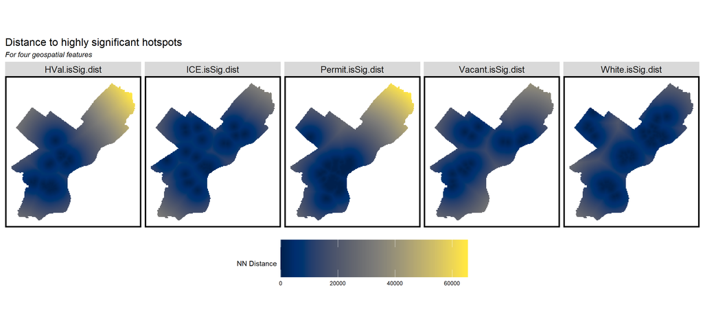

```r
final_net %>%
  dplyr::select(Permit.isSig.dist,
                ICE.isSig.dist,
                HVal.isSig.dist,
                Vacant.isSig.dist, White.isSig.dist) %>%
  pivot_longer(where(is.numeric), names_to = "Variable", values_to = "Value") %>%
  ggplot() +
    geom_sf(aes(fill=Value), color=NA) +
    scale_fill_viridis(name="NN Distance", option="E") +
    labs(title="Distance to highly significant hotspots",
         subtitle = "For four geospatial features") +
    facet_wrap(~Variable, nrow = 1) +
    theme(legend.position="bottom",
          legend.key.size = unit(0.8, 'in')) +
    mapTheme()
```

## 2.3 Correlation and Relationships Analysis

After exploring our features and generating new ones for our models, we set out to study the possible relationships. This analysis assists us in deciding which variables we will use in our poisson regression model. We began with a correlation matrix, pictured below.

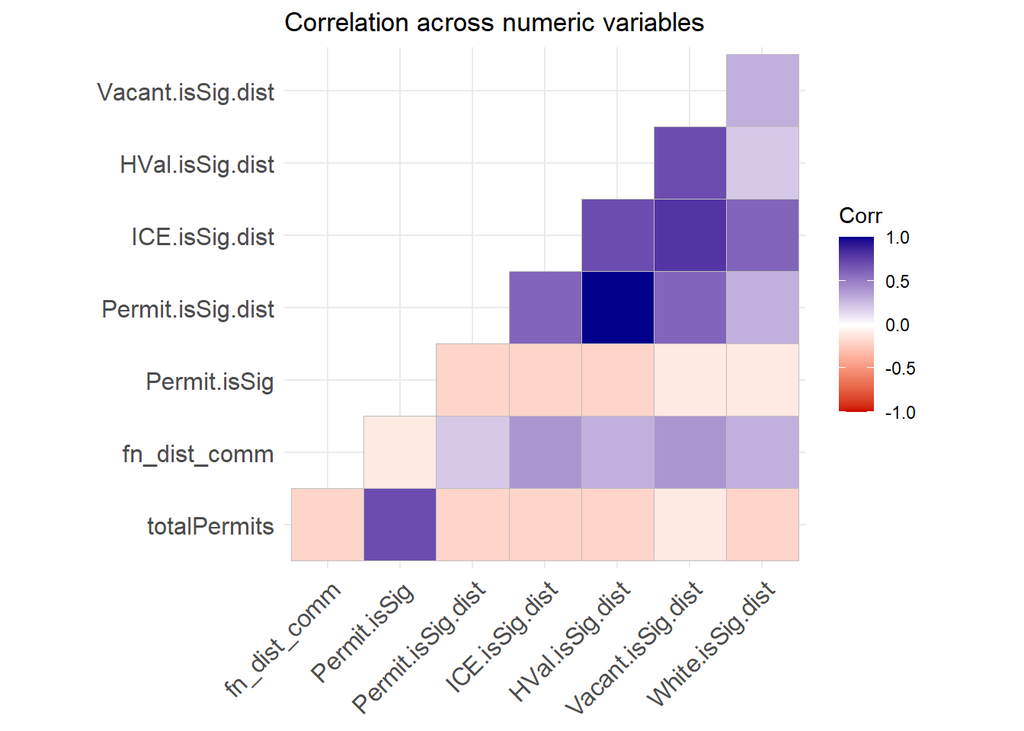

```r
numericVars <-
  select_if(st_drop_geometry(final_net), is.numeric) %>%
  select(-cvID) %>%
  na.omit()

ggcorrplot(
  round(cor(numericVars), 1),
  p.mat = cor_pmat(numericVars),
  colors = c("red3", "white", "blue4"),
  type="lower",
  insig = "blank"#, lab=TRUE #uncomment to show labels
  )+
    labs(title = "Correlation across numeric variables")
```

### 2.3.1 Correlation Scatterplots

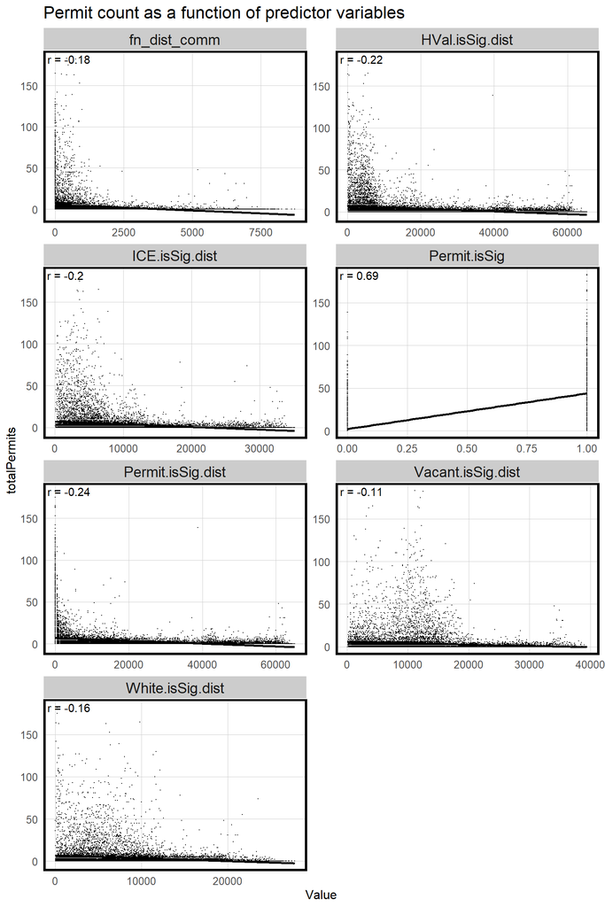

```r
correlation.long <-
  st_drop_geometry(final_net) %>%
    dplyr::select(-uniqueID, -cvID, -range) %>%
    gather(Variable, Value, -totalPermits)

correlation.cor <-
  correlation.long %>%
    group_by(Variable) %>%
    summarize(correlation = cor(Value, totalPermits, use = "complete.obs"))

ggplot(correlation.long, aes(Value, totalPermits)) +
  ggplot2::geom_point(size = 0.1) +
  geom_text(data = correlation.cor, aes(label = paste("r =", round(correlation, 2))),
            x=-Inf, y=Inf, vjust = 1.5, hjust = -.1) +
  geom_smooth(method = "lm", se = FALSE, colour = "black") +
  facet_wrap(~Variable, ncol = 2, scales = "free") +
  labs(title = "Permit count as a function of predictor variables",
       strip.text.x = element_text(size=10)) +
  plotTheme()
```

## 2.4 Modeling

To get more insight into the performance of our model, we set up two models, with different predictor variables. One contained the permit hotspots and the distance to those permit hotspots and the other excluded them.

The rest of the indicators that we engineered, such as the the distances to socioeconomic change hotspots and to commercial corridors, will be present in both.

```r
reg.vars.permit <- c("Permit.isSig.dist", "Permit.isSig",
                     "White.isSig.dist",
              "ICE.isSig.dist","HVal.isSig.dist","Vacant.isSig.dist",
              "fn_dist_comm")

reg.vars <- c("White.isSig.dist",
              "ICE.isSig.dist","HVal.isSig.dist","Vacant.isSig.dist",
              "fn_dist_comm")
```

We then performed two separate leave-one-group-out spatial cross validations (LOGO-CV) to test the performance of the models. The hold-out groups in our test were the neighborhoods of Philadelphia, which we joined and assigned to each fishnet cell for the purpose of this analysis.

```r
set.seed(888)

reg.permit.spatialCV <- crossValidate(
    dataset = final_net_reg,
    id = "name",
    dependentVariable = "totalPermits",
    indVariables = reg.vars.permit) %>%
  dplyr::select(cvID = name, totalPermits, Prediction, geometry)

reg.spatialCV <- crossValidate(
    dataset = final_net_reg,
    id = "name",
    dependentVariable = "totalPermits",
    indVariables = reg.vars) %>%
  dplyr::select(cvID = name, totalPermits, Prediction, geometry)
```

## 2.5 Long-Term Model Cross Validation Results

The following visualizations compare the errors of each model’s cross-validation.

### 2.5.1 Histogram and Summary Table of CV Results

We observe that adding the distance to a permit hotspot helps to reduce our errors, increasing the frequency of folds with 0-3 errors. This provides support for the idea that the distance to permit hotspots is an important indicator of future development activity.

There are less outliers when the distance to permit hotspots is included. However, we still have outliers. It could be that our model underpredicts in areas with high counts of development permits. The next set of maps will to help clarify where we are getting our highest errors.

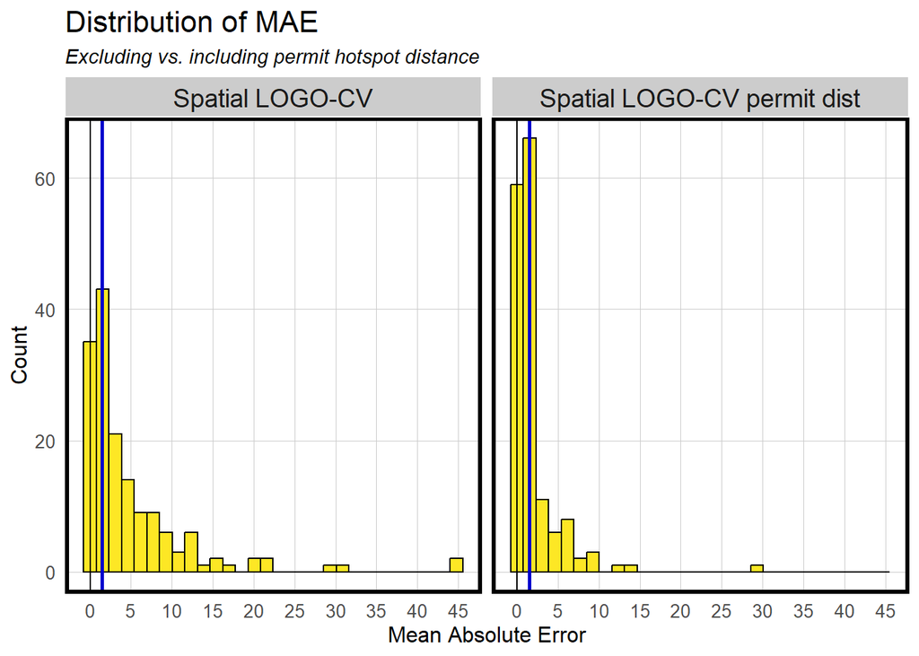

```r
reg.summary <-
  rbind(mutate(reg.spatialCV, Error = Prediction - totalPermits,
           Regression = "Spatial LOGO-CV"),
        mutate(reg.permit.spatialCV, Error = Prediction - totalPermits,
           Regression = "Spatial LOGO-CV permit dist")) %>%
  st_sf()

error_by_reg_and_fold <-
  reg.summary %>%
  group_by(Regression, cvID) %>%
  summarize(Mean_Error = mean(Prediction - totalPermits, na.rm = T),
            MAE = mean(abs(Mean_Error), na.rm = T),
            SD_MAE = mean(abs(Mean_Error), na.rm = T)) %>%
  ungroup()

error_by_reg_and_fold %>%
  ggplot(aes(MAE)) +
    geom_histogram(bins = 30, colour="black", fill = "#FDE725FF") +
    facet_wrap(~Regression) +
    geom_vline(xintercept = 0) + scale_x_continuous(breaks = seq(0, 50, by = 5)) +
    geom_vline(aes(xintercept = median(MAE)), col='blue3', size = 1) +
    labs(title="Distribution of MAE", subtitle = "Excluding vs. including permit hotspot distance",
         x="Mean Absolute Error", y="Count") +
    plotTheme()
```

This summary table confirms the utility of the distance to permit hotspot feature. Overall, the model becomes more accurate and precise. The MAE and its standard deviation are greatly reduced when that indicator is employed as a predictor in the model.

```r
st_drop_geometry(error_by_reg_and_fold) %>%
  group_by(Regression) %>%
    summarize(Mean_MAE = round(mean(MAE), 2),
              SD_MAE = round(sd(MAE), 2)) %>%
  kable() %>%
    kable_styling("striped", full_width = F) %>%
    row_spec(2, color = "black", background = "#FDE725FF") #%>%
```

| Regression | Mean_MAE | SD_MAE |
| --- | --- | --- |
| Spatial LOGO-CV | 4.92 | 7.04 |
| Spatial LOGO-CV permit dist | 2.04 | 3.15 |

```r
    #row_spec(4, color = "black", background = "#FDE725FF")
```

### 2.5.2 Long-Term Model: Map of Errors

These maps of average fold errors across neighborhoods further emphasize that adding the distance from permit hotspots reduces our errors and makes them more evenly distributed across space (seen in the map on the right). Given that greatest our errors are in Point Breeze, Center City, and a section of North Philadelphia near Temple University, we suspect that our model underpredicts the higher counts of permits, but are ultimately satisfied with its ability to predict well across Philadelphia.

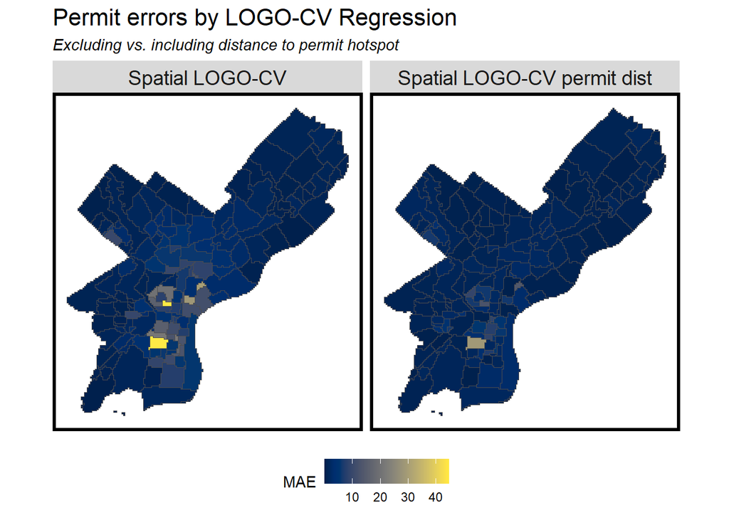

```r
error_by_reg_and_fold %>%
  ggplot() +
    geom_sf(aes(fill = MAE),
            color = "gray30") +
    facet_wrap(~Regression) +
    scale_fill_viridis(option="cividis") +
    labs(title = "Permit errors by LOGO-CV Regression",
         subtitle = "Excluding vs. including distance to permit hotspot") +
    mapTheme() + theme(legend.position="bottom")
```

## 2.6 Long-Term Model: Generalizability Test

The below summary table shows that, again, the mean of errors are lower in the model that includes permit hotspot related features. It also shows that our model underpredicts permit incidence in block groups above the median and slightly overpredicts permit counts in block groups under the median.

The average margin of errors, however, is quite small. That there is a discrepancy in the errors means that our model could be fine-tuned further, but it is still predicting well.

```r
phlblockgroups.sf <- phlblockgroups.sf %>%
  mutate(IncomeContext = ifelse(MedHHInc19 > 41416, "Above_Median", "Below_Median"))

reg.summary %>%
    st_centroid() %>%
    st_join(phlblockgroups.sf) %>%
    na.omit() %>%
    st_drop_geometry() %>%
    group_by(Regression, IncomeContext) %>%
    summarize(mean.Error = mean(Error, na.rm = T)) %>%
    spread(IncomeContext, mean.Error) %>%
    kable(caption = "Mean Error by Block Group Income Context") %>%
    kable_styling("striped", full_width = F) %>%
  row_spec(1, color = "white", background = "#383120") %>%
  row_spec(2, color = "black", background = "#de9f00")
```

Mean Error by Block Group Income Context

| Regression | Above_Median | Below_Median |
| --- | --- | --- |
| Spatial LOGO-CV | -1.3843994 | 1.6624208 |
| Spatial LOGO-CV permit dist | -0.4262288 | 0.1544894 |

## 2.7 Long-Term Model: Kernel Density Comparison

Here, we generate a kernel density map of permits, then use both kernel density and our prediction model to assign fishnet cells to “risk categories”, or percentile ranges of predicted permit frequency in 2019. The results are displayed in the maps below, with actual 2019 permit locations mapped across them.

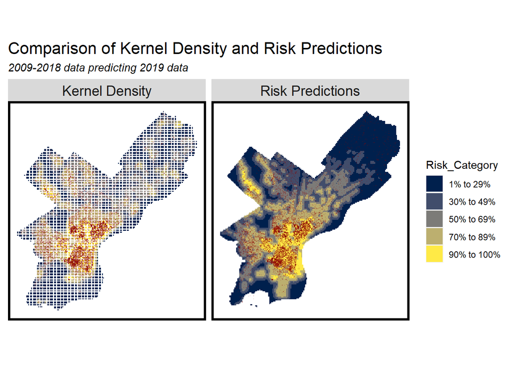

```r
permit_ppp <- as.ppp(st_coordinates(cpfinal_0923.sf), W = st_bbox(final_net))
permit_KD <- spatstat.explore::density.ppp(permit_ppp, 1000)

permit_KDE_sf <- as.data.frame(permit_KD) %>%
  st_as_sf(coords = c("x", "y"), crs = st_crs(final_net)) %>%
  aggregate(., final_net, mean) %>%
  mutate(label = "Kernel Density",
         Risk_Category = ntile(value, 100),
         Risk_Category = case_when(
           Risk_Category >= 90 ~ "90% to 100%",
           Risk_Category >= 70 & Risk_Category <= 89 ~ "70% to 89%",
           Risk_Category >= 50 & Risk_Category <= 69 ~ "50% to 69%",
           Risk_Category >= 30 & Risk_Category <= 49 ~ "30% to 49%",
           Risk_Category >= 1 & Risk_Category <= 29 ~ "1% to 29%")) %>%
  cbind(
    aggregate(
      dplyr::select(cpfinal_19.sf) %>% mutate(totalPermits = 1), ., sum) %>%
    mutate(totalPermits = replace_na(totalPermits, 0))) %>%
  dplyr::select(label, Risk_Category, totalPermits)

permit_reg_sf <-
  filter(reg.summary, Regression == "Spatial LOGO-CV permit dist") %>%
  mutate(label = "Risk Predictions",
         Risk_Category = ntile(Prediction, 100),
         Risk_Category = case_when(
           Risk_Category >= 90 ~ "90% to 100%",
           Risk_Category >= 70 & Risk_Category <= 89 ~ "70% to 89%",
           Risk_Category >= 50 & Risk_Category <= 69 ~ "50% to 69%",
           Risk_Category >= 30 & Risk_Category <= 49 ~ "30% to 49%",
           Risk_Category >= 1 & Risk_Category <= 29 ~ "1% to 29%")) %>%
  cbind(
    aggregate(
      dplyr::select(cpfinal_19.sf) %>% mutate(totalPermits = 1), ., sum) %>%
      mutate(totalPermits = replace_na(totalPermits, 0))) %>%
  dplyr::select(label,Risk_Category, totalPermits)

rbind(permit_KDE_sf, permit_reg_sf) %>%
  na.omit() %>%
  gather(Variable, Value, -label, -Risk_Category, -geometry) %>%
  ggplot() +
    geom_sf(aes(fill = Risk_Category), colour = NA) +
    geom_sf(data = cpfinal_19.sf, size = 0.05, color = "red4", alpha = 0.1) +
    facet_wrap(~label) +
    scale_fill_viridis(discrete = TRUE, option = "E") +
    labs(title="Comparison of Kernel Density and Risk Predictions",
         subtitle="2009-2018 data predicting 2019 data") +
    mapTheme()
```

### 2.7.1 Kernel Density vs Long-Term Model Bar Chart

The following bar chart compares the performance of our prediction model against that of a simple kernel density function. Although kernel density appears to predict 2019 permits with more precision, it may leave less room for bias that may be introduced by policy actions that are difficult to measure, such as Keystone Opportunity Zones and other tax incentives that are not associated with publicly available data.

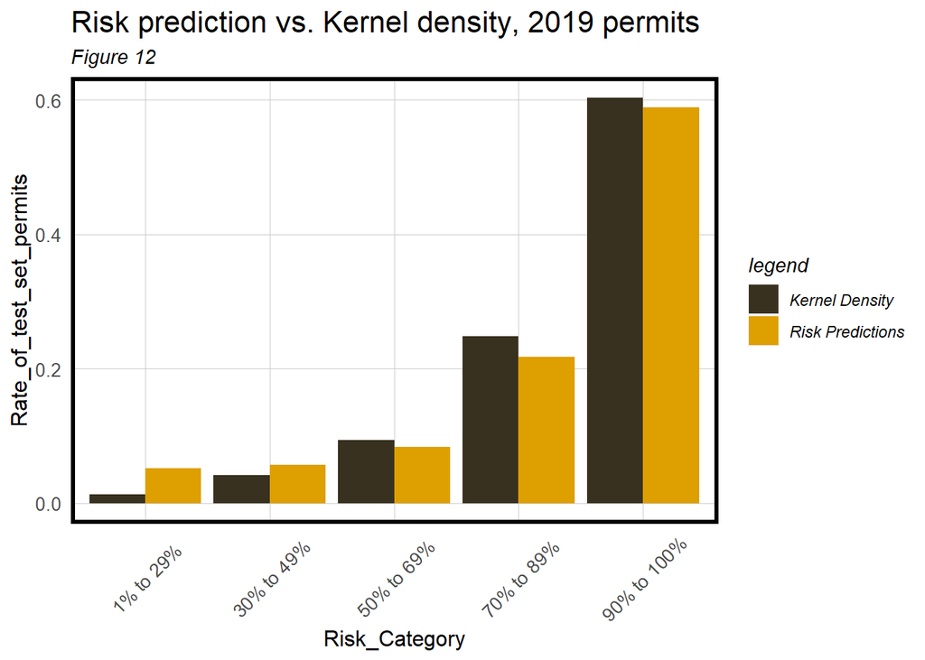

```r
rbind(permit_KDE_sf, permit_reg_sf) %>%
  st_set_geometry(NULL) %>% na.omit() %>%
  gather(Variable, Value, -label, -Risk_Category) %>%
  group_by(label, Risk_Category) %>%
  summarize(totalPermits = sum(Value)) %>%
  ungroup() %>%
  group_by(label) %>%
  mutate(Rate_of_test_set_permits = totalPermits / sum(totalPermits)) %>%
    ggplot(aes(Risk_Category,Rate_of_test_set_permits)) +
      geom_bar(aes(fill=label), position="dodge", stat="identity") +
      scale_fill_manual ("legend", values = c("Kernel Density" = "#383120", "Risk Predictions" = "#de9f00")) +
      labs(title = "Risk prediction vs. Kernel density, 2019 permits",
           subtitle = "Figure 12") +
      plotTheme() + theme(axis.text.x = element_text(angle = 45, vjust = 0.5))
```

## 2.8 Long-Term Model: Predicted Hotspots Map

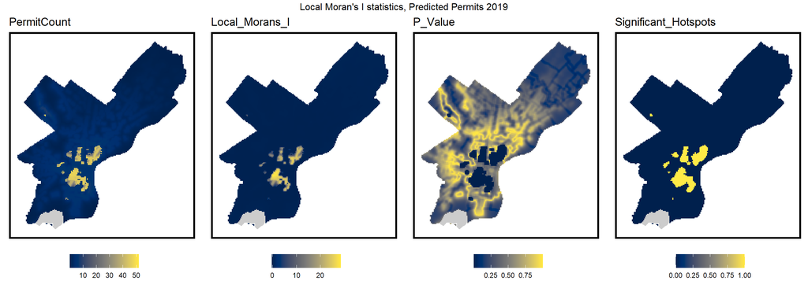

```r
reg.summary.morans <- reg.summary %>%
  dplyr::filter(Regression == "Spatial LOGO-CV permit dist")

reg.summary.morans.nb <- poly2nb(as_Spatial(reg.summary.morans), queen=TRUE)
reg.summary.morans.weights <- nb2listw(reg.summary.morans.nb, style="W", zero.policy=TRUE)

local_morans <- localmoran(reg.summary.morans$Prediction,
                           reg.summary.morans.weights,
                           zero.policy=TRUE) %>%
                as.data.frame()

final_predict.localMorans.Permit <-
  cbind(local_morans, as.data.frame(reg.summary.morans)) %>%
  st_sf() %>%
  dplyr::select(PermitCount = Prediction,
                Local_Morans_I = Ii,
                P_Value = `Pr(z != E(Ii))`) %>%
  mutate(Significant_Hotspots = ifelse(P_Value <= 0.000001, 1, 0)) %>%
  gather(Variable, Value, -geometry)

vars <- unique(final_predict.localMorans.Permit$Variable)
varList <- list()

for(i in vars){
  varList[[i]] <-
    ggplot() +
      geom_sf(data = nhoods, color = "transparent", fill = "gray80") +
      geom_sf(data = filter(final_predict.localMorans.Permit, Variable == i),
              aes(fill = Value), colour=NA) +
      scale_fill_viridis(option = "E", name="") +
      labs(title=i) +
      mapTheme(title_size = 14) + theme(legend.position="bottom")}

do.call(grid.arrange,c(varList, ncol = 4, top = "Local Moran's I statistics, Predicted Permits 2019"))
```

# 3 Short-Term Model Methods and Results

Now we will create and analyze a short-term model to predict total counts of development related permit across Philadelphia for 2023. We refer to this model as short-term because we will only train it on permit counts between 2021-2022.

The model will include the same 2013-2019 socioeconomic hotspot-distance indicators that we used in the long-term model. The key difference here is that we are only using 2 years worth of permit data (2021-2022) instead of 10 years.

The purpose is to evaluate the cost of beginning to document permit types in jurisdictions interested in defining their hotspots for future planning initiatives at the neighborhood level.

Using this break also made sense because of the COVID-19 pandemic and resulting lockdown. Moreover, as we mentioned before, the type of work value definitions were changed after 2020. The observations of permits between 2021-2022 made sense to use for our short-term analysis, skipping the value of 2020 as an abnormal year.

## 3.1 Fishnet of Permits 2021-2022

Again, we start with an an exploratory analysis. We create a map of the count of permits per fishnet cell.

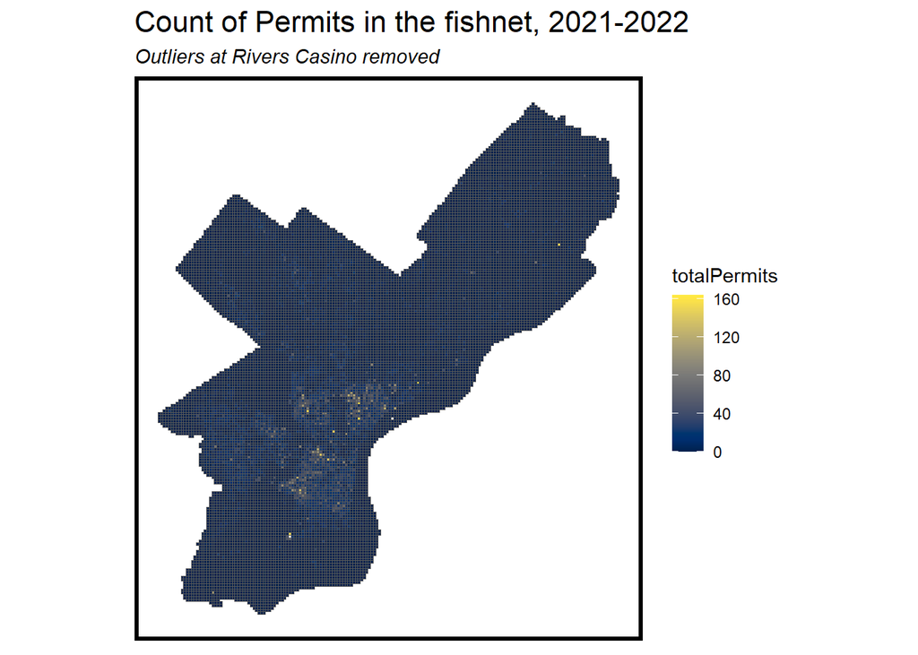

```r
permit_net_2122 <-
  dplyr::select(cpfinal_2122.sf) %>%
  mutate(totalPermits = 1) %>%
  aggregate(., fishnet, sum) %>%
  mutate(totalPermits = replace_na(totalPermits, 0),
         uniqueID = rownames(.),
         cvID = sample(round(nrow(fishnet) / 24),
                       size=nrow(fishnet), replace = TRUE),
         range = "2021-2022")

#change to visualize 2009-2018 vs 2021-2022 - need to merge permit_net with new one

permit_net_2122 %>%
  filter(totalPermits < 300) %>%
  ggplot() +
    geom_sf(aes(fill = totalPermits)) +
    scale_fill_viridis(option="cividis")+
    labs(title = "Count of Permits in the fishnet, 2021-2022",
         subtitle = "Outliers at Rivers Casino removed") +
    mapTheme()
```

```r
permit_net_2122 <- st_drop_geometry(permit_net_2122)
final_net_2122 <- left_join(fishnet, permit_net_2122, by = "uniqueID")

# redoing dist to commercial with new fishnet
nearest_fts_fn <- sf::st_nearest_feature(final_net_2122, corridors)
m <- rsgeo::as_rsgeo(final_net_2122)
final_net_2122$fn_dist_comm <- rsgeo::distance_euclidean_pairwise(m, j[nearest_fts_fn])
```

## 3.2 Local Moran’s I: Permit Hotspot identification and Distance Calculation

Because we are now using permits from 2021-2022, we recalculate the permit hotspots for this dataset and assign the distance to the nearest hotspot value to each fishnet cell.

This is one way that our model is different from the long-term model. Our permit hotspot distance-from indicator is based on the permits that we are using for this model, not the 2009-2018.

```r
final_net_2122.nb <- poly2nb(as_Spatial(final_net_2122), queen=TRUE)
final_net_2122.weights <- nb2listw(final_net_2122.nb, style="W", zero.policy=TRUE)

final_net_2122 <- final_net_2122 %>%
    mutate(Permit.isSig = ifelse(localmoran(final_net_2122$totalPermits,
                             final_net_2122.weights)[,5] <= 0.00001, 1, 0))
final_net_2122 <- final_net_2122 %>%
    mutate(Permit.isSig.dist = nn_function(st_coordinates(st_centroid(final_net_2122)),
                            st_coordinates(st_centroid(filter(final_net_2122,
                                                              final_net_2122$Permit.isSig == 1))),1),
           ICE.isSig.dist = nn_function(st_coordinates(st_centroid(final_net_2122)),
                            st_coordinates(st_centroid(filter(phlblockgroups.sf,
                                                              phlblockgroups.sf$ICE.isSig == 1))),1),
           HVal.isSig.dist = nn_function(st_coordinates(st_centroid(final_net_2122)),
                            st_coordinates(st_centroid(filter(phlblockgroups.sf,
                                                              phlblockgroups.sf$HVal.isSig == 1))),1),
           Vacant.isSig.dist = nn_function(st_coordinates(st_centroid(final_net_2122)),
                            st_coordinates(st_centroid(filter(phlblockgroups.sf,
                                                              phlblockgroups.sf$Vacant.isSig == 1))),1),
           White.isSig.dist = nn_function(st_coordinates(st_centroid(final_net_2122)),
                            st_coordinates(st_centroid(filter(phlblockgroups.sf,
                                                              phlblockgroups.sf$White.isSig == 1))),1),
           )

# neighborhoods for logo-cv
final_net_reg_2122 <-
  final_net_2122 %>%
  st_join(dplyr::select(nhoods, name)) %>%
  mutate(name = ifelse(is.na(name), "OTHER", name)) %>%
  filter(!name %in% c("AIRPORT"))
```

## 3.3 Short-Term Model Correlation Analysis

We review the strength of relationships between variables before using them in our model. We expect it to be similar to the long-term correlation matrix.

### 3.3.1 Correlation Matrix

At a glance, the relationship between the distance from a permit hotspot to the observed total count of permits is weaker than in the long-term model. Conversely, the distances from socioeconomic change hotspots play a stronger part in determining the total count of permits. This suggests that at the short-term scale observed permit counts are more sensitive to demographic changes than at the long-term scale.

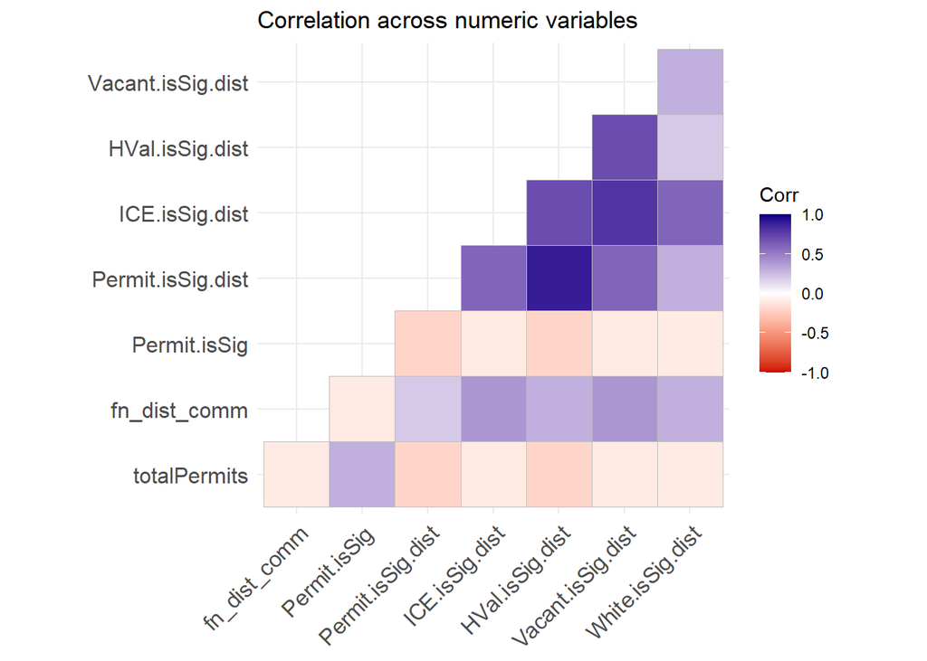

```r
numericVars <-
  select_if(st_drop_geometry(final_net_2122), is.numeric) %>%
  select(-cvID) %>%
  na.omit()

ggcorrplot(
  round(cor(numericVars), 1),
  p.mat = cor_pmat(numericVars),
  colors = c("red3", "white", "blue4"),
  type="lower",
  insig = "blank"#, lab=TRUE #uncomment to show labels
  )+
    labs(title = "Correlation across numeric variables")
```

## 3.4 Short-Term Model Cross-Validation Test and Results

As in the long-term model, we performed a leave one group out cross validation test for our regression model using neighborhoods as folds. We compare the performance of the model when the distance to permit hotspots is included or missing.

```r
reg.permit.spatialCV_2122 <- crossValidate(
    dataset = final_net_reg_2122,
    id = "name",
    dependentVariable = "totalPermits",
    indVariables = reg.vars.permit) %>%
  dplyr::select(cvID = name, totalPermits, Prediction, geometry)

reg.spatialCV_2122 <- crossValidate(
    dataset = final_net_reg_2122,
    id = "name",
    dependentVariable = "totalPermits",
    indVariables = reg.vars) %>%
  dplyr::select(cvID = name, totalPermits, Prediction, geometry)
```

### 3.4.1 Histogram and Summary Table

The spread of errors is narrower and closer to the mean when the permit hotspot distance indicator is included. Outliers are decreased and the frequency of extremely low values increases compared to when it is not included.

One difference between these distributions is that there are no clear outstanding errors. We hypothesize that this is because our total permit count is over a short period of years. The implication is that in the long-term model we underpredict at the high percentile of observed permit counts because some cells have multi-year accumulations built into their values.

Overall, although we would like to optimize for the least amount of error, we think that the short-term model performs similarly to the long-term model.

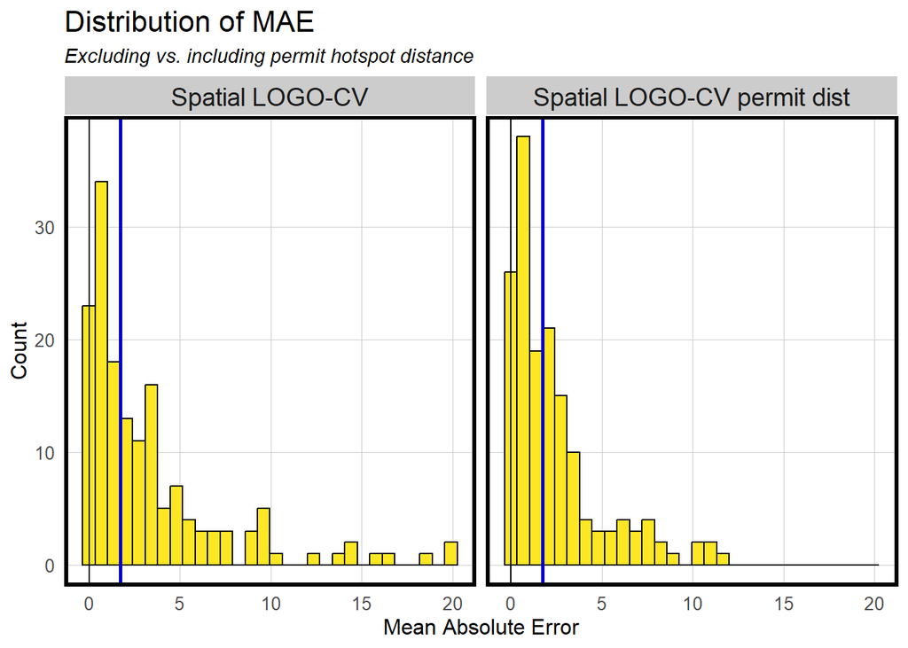

```r
reg.summary_2122 <-
  rbind(mutate(reg.spatialCV_2122, Error = Prediction - totalPermits,
           Regression = "Spatial LOGO-CV"),
        mutate(reg.permit.spatialCV_2122, Error = Prediction - totalPermits,
           Regression = "Spatial LOGO-CV permit dist")) %>%
  st_sf()

error_by_reg_and_fold_2122 <-
  reg.summary_2122 %>%
  group_by(Regression, cvID) %>%
  summarize(Mean_Error = mean(Prediction - totalPermits, na.rm = T),
            MAE = mean(abs(Mean_Error), na.rm = T),
            SD_MAE = mean(abs(Mean_Error), na.rm = T)) %>%
  ungroup()

error_by_reg_and_fold_2122 %>%
  ggplot(aes(MAE)) +
    geom_histogram(bins = 30, colour="black", fill = "#FDE725FF") +
    facet_wrap(~Regression) +
    geom_vline(xintercept = 0) + scale_x_continuous(breaks = seq(0, 50, by = 5)) +
    geom_vline(aes(xintercept = median(MAE)), col='blue3', size = 1) +
    labs(title="Distribution of MAE", subtitle = "Excluding vs. including permit hotspot distance",
         x="Mean Absolute Error", y="Count") +
    plotTheme()
```

The tables below compare each model’s errors. They both confirm the important role of permit hotspot identification in making the model more accurate.

The other main takeaway is that whether our model is trained on 10 years worth of permits, or 2 years, it will do a good job at predicting total permit counts for the following year. An average margin of error of 3 development-related permits per fishnet cell is acceptable for us as a preliminary result.

```r
table1 <- st_drop_geometry(error_by_reg_and_fold) %>%
  group_by(Regression) %>%
    summarize(Mean_MAE = round(mean(MAE), 2),
              SD_MAE = round(sd(MAE), 2))

table2 <- st_drop_geometry(error_by_reg_and_fold_2122) %>%
  group_by(Regression) %>%
    summarize(Mean_MAE = round(mean(MAE), 2),
              SD_MAE = round(sd(MAE), 2))

kable(table1, caption = "Long-Term Model LOGO-CV: With and Without Permit Hotspot Distance") %>%
    kable_styling("striped", full_width = F, position = "float_left") %>%
    row_spec(2, color = "black", background = "#FDE725FF")
```

Long-Term Model LOGO-CV: With and Without Permit Hotspot Distance

| Regression | Mean_MAE | SD_MAE |
| --- | --- | --- |
| Spatial LOGO-CV | 4.92 | 7.04 |
| Spatial LOGO-CV permit dist | 2.04 | 3.15 |

```r
kable(table2, caption = "Short-Term Model LOGO-CV: With and without Permit Hotspot Distance") %>%
    kable_styling("striped", full_width = F, position = "left") %>%
    row_spec(2, color = "black", background = "#FDE725FF")
```

Short-Term Model LOGO-CV: With and without Permit Hotspot Distance

| Regression | Mean_MAE | SD_MAE |
| --- | --- | --- |
| Spatial LOGO-CV | 3.39 | 4.06 |
| Spatial LOGO-CV permit dist | 2.40 | 2.58 |

### 3.4.2 Short-Term Model: Map of Errors Comparison

An implication of this is that using short-term permit counts can be as useful as long-term, but the model is more sensitive to the local context in ways that we have yet to uncover. A key goal would be to reduce the errors that we see spread around the city.

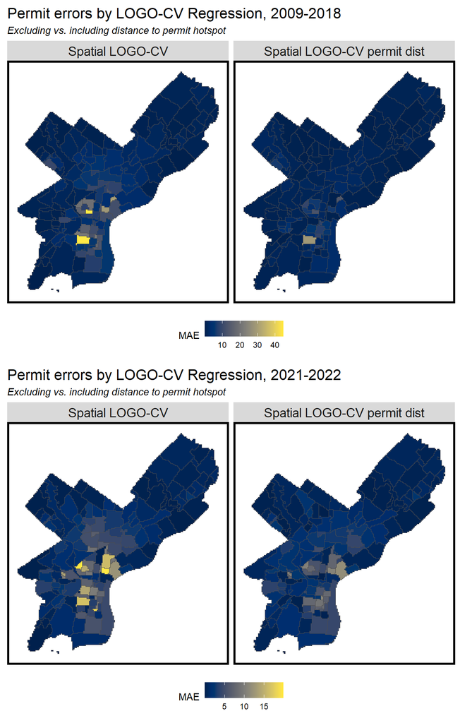

```r
grid.arrange(nrow=2,
error_by_reg_and_fold %>%
  ggplot() +
    geom_sf(aes(fill = MAE),
            color = "gray30") +
    facet_wrap(~Regression) +
    scale_fill_viridis(option="cividis") +
    labs(title = "Permit errors by LOGO-CV Regression, 2009-2018",
         subtitle = "Excluding vs. including distance to permit hotspot") +
    mapTheme() + theme(legend.position="bottom")
,
error_by_reg_and_fold_2122 %>%
  ggplot() +
    geom_sf(aes(fill = MAE),
            color = "gray30") +
    facet_wrap(~Regression) +
    scale_fill_viridis(option="cividis") +
    labs(title = "Permit errors by LOGO-CV Regression, 2021-2022",
         subtitle = "Excluding vs. including distance to permit hotspot") +
    mapTheme() + theme(legend.position="bottom")
)
```

## 3.5 Short-Term Model: Kernel Density Comparison

We generated a similar comparison between a kernel density map of permits and a map of our prediction model. The results are displayed below, with actual 2023 permit locations mapped across each map.

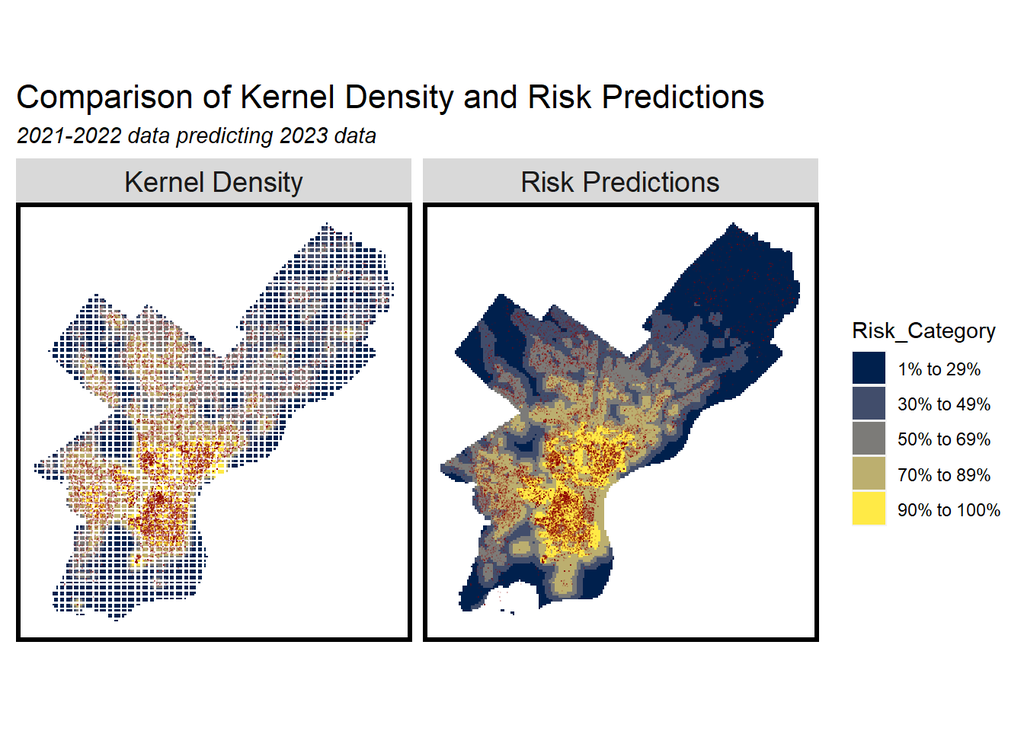

```r
permit_ppp_23 <- as.ppp(st_coordinates(cpfinal_2122.sf), W = st_bbox(final_net_2122))
permit_KD_23 <- spatstat.explore::density.ppp(permit_ppp_23, 1000)

permit_KDE_sf_23 <- as.data.frame(permit_KD_23) %>%
  st_as_sf(coords = c("x", "y"), crs = st_crs(final_net_2122)) %>%
  aggregate(., final_net_2122, mean) %>%
  mutate(label = "Kernel Density",
         Risk_Category = ntile(value, 100),
         Risk_Category = case_when(
           Risk_Category >= 90 ~ "90% to 100%",
           Risk_Category >= 70 & Risk_Category <= 89 ~ "70% to 89%",
           Risk_Category >= 50 & Risk_Category <= 69 ~ "50% to 69%",
           Risk_Category >= 30 & Risk_Category <= 49 ~ "30% to 49%",
           Risk_Category >= 1 & Risk_Category <= 29 ~ "1% to 29%")) %>%
  cbind(
    aggregate(
      dplyr::select(cpfinal_23.sf) %>% mutate(totalPermits = 1), ., sum) %>%
    mutate(totalPermits = replace_na(totalPermits, 0))) %>%
  dplyr::select(label, Risk_Category, totalPermits)

permit_reg_sf_23 <-
  filter(reg.summary_2122, Regression == "Spatial LOGO-CV permit dist") %>%
  mutate(label = "Risk Predictions",
         Risk_Category = ntile(Prediction, 100),
         Risk_Category = case_when(
           Risk_Category >= 90 ~ "90% to 100%",
           Risk_Category >= 70 & Risk_Category <= 89 ~ "70% to 89%",
           Risk_Category >= 50 & Risk_Category <= 69 ~ "50% to 69%",
           Risk_Category >= 30 & Risk_Category <= 49 ~ "30% to 49%",
           Risk_Category >= 1 & Risk_Category <= 29 ~ "1% to 29%")) %>%
  cbind(
    aggregate(
      dplyr::select(cpfinal_23.sf) %>% mutate(totalPermits = 1), ., sum) %>%
      mutate(totalPermits = replace_na(totalPermits, 0))) %>%
  dplyr::select(label,Risk_Category, totalPermits)

rbind(permit_KDE_sf_23, permit_reg_sf_23) %>%
  na.omit() %>%
  gather(Variable, Value, -label, -Risk_Category, -geometry) %>%
  ggplot() +
    geom_sf(aes(fill = Risk_Category), color = "transparent") +
    geom_sf(data = cpfinal_23.sf, size = 0.05, color = "red4", alpha = 0.1) +
    facet_wrap(~label, ) +
    scale_fill_viridis(discrete = TRUE, option = "E") +
    labs(title="Comparison of Kernel Density and Risk Predictions",
         subtitle="2021-2022 data predicting 2023 data") +
    mapTheme()
```

### 3.5.1 Kernel Density Comparison: Bar Chart

We think that the bar chart is a good way to compare the performance of our model to the kernel density approach. One thing that we like here is that our model does better than kernel density across all percentiles of count values except for the highest ones.

We think that in implication of our model is the ability to detect mid-range activity of development because they could be emerging areas that could turn into hotspots. It would be important to be able to identify them so it is good that we outperform the kernel density prediction in the other categories.

We believe that the kernel density outperforms our short-term model at the highest category because it is dependent on concentrations can better anticipate those areas. Our models sacrifice the ability to predict the highest counts of permits for the ability to predict for the other ranges of values. As we will see, we do not lose the ability to detect future hotspots of development in the process.

The performance of this short-term model appears to match and even exceed that of the long-term model when compared to kernel density, suggesting that short-term phases for permit prediction are still effective.

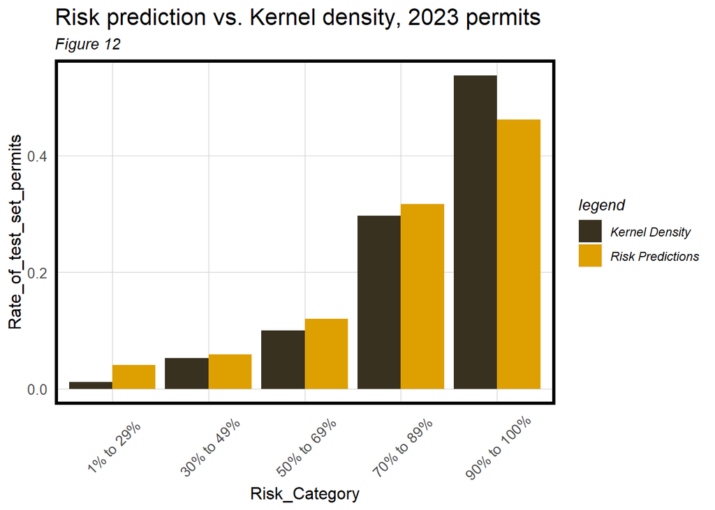

```r
rbind(permit_KDE_sf_23, permit_reg_sf_23) %>%
  st_set_geometry(NULL) %>% na.omit() %>%
  gather(Variable, Value, -label, -Risk_Category) %>%
  group_by(label, Risk_Category) %>%
  summarize(totalPermits = sum(Value)) %>%
  ungroup() %>%
  group_by(label) %>%
  mutate(Rate_of_test_set_permits = totalPermits / sum(totalPermits)) %>%
    ggplot(aes(Risk_Category,Rate_of_test_set_permits)) +
      geom_bar(aes(fill=label), position="dodge", stat="identity") +
      scale_fill_manual ("legend", values = c("Kernel Density" = "#383120", "Risk Predictions" = "#de9f00")) +
      labs(title = "Risk prediction vs. Kernel density, 2023 permits",
           subtitle = "Figure 12") +
      plotTheme() + theme(axis.text.x = element_text(angle = 45, vjust = 0.5))
```

## 3.6 Short-Term Model: Predicted Permit Hotspot Map Comparison

The result of our short-term model is a permit hotspot prediction for 2023. To create these hotspots, we ran a local Moran’s I test on the 2023 permit counts that our model predicted to identify the hotspots. A walkthrough of that process is visualized below.

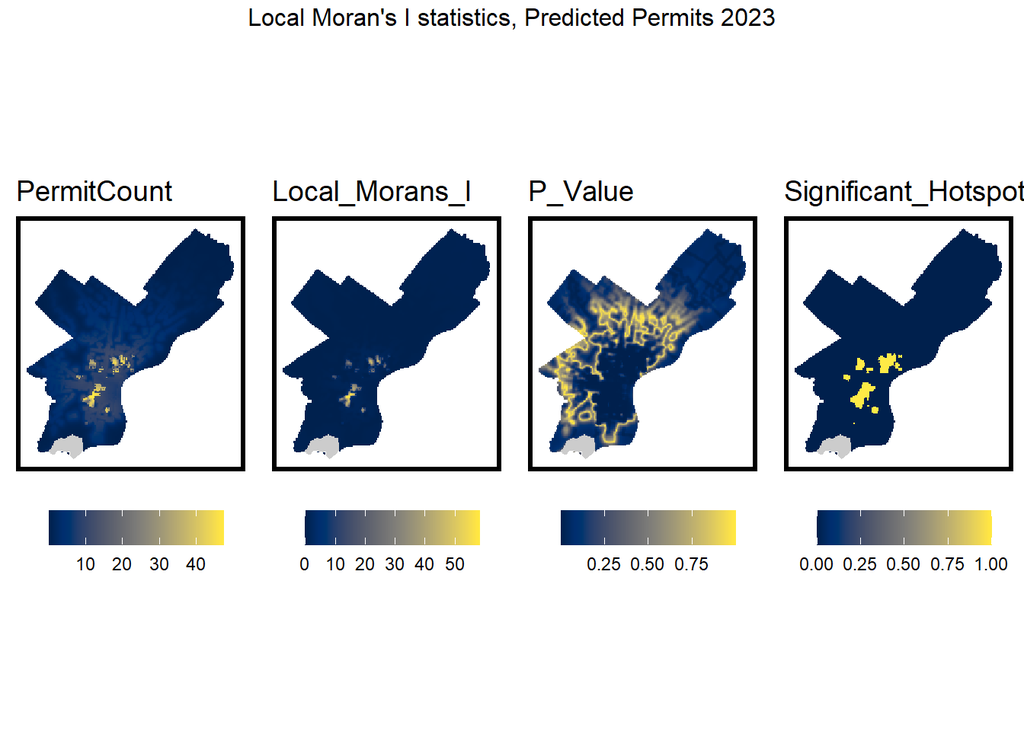

```r
reg.summary.morans_2122 <- reg.summary_2122 %>%
  dplyr::filter(Regression == "Spatial LOGO-CV permit dist")

reg.summary.morans.nb_2122 <- poly2nb(as_Spatial(reg.summary.morans_2122), queen=TRUE)
reg.summary.morans.weights_2122 <- nb2listw(reg.summary.morans.nb_2122, style="W", zero.policy=TRUE)

local_morans_2122 <- localmoran(reg.summary.morans_2122$Prediction,
                           reg.summary.morans.weights_2122,
                           zero.policy=TRUE) %>%
                as.data.frame()

final_predict.localMorans.Permit_2122 <-
  cbind(local_morans_2122, as.data.frame(reg.summary.morans_2122)) %>%
  st_sf() %>%
  dplyr::select(PermitCount = Prediction,
                Local_Morans_I = Ii,
                P_Value = `Pr(z != E(Ii))`) %>%
  mutate(Significant_Hotspots = ifelse(P_Value <= 0.000001, 1, 0)) %>%
  gather(Variable, Value, -geometry)

vars <- unique(final_predict.localMorans.Permit_2122$Variable)
varList <- list()

for(i in vars){
  varList[[i]] <-
    ggplot() +
      geom_sf(data = nhoods, color = "transparent", fill = "gray80") +
      geom_sf(data = filter(final_predict.localMorans.Permit_2122, Variable == i),
              aes(fill = Value), colour=NA) +
      scale_fill_viridis(option = "E", name="") +
      labs(title=i) +
      mapTheme(title_size = 14) + theme(legend.position="bottom")}

do.call(grid.arrange,c(varList, ncol = 4, top = "Local Moran's I statistics, Predicted Permits 2023"))
```

The following comparison is the most significant in our report. Here, we have the long-term model’s predicted hotspot map on the left and the short-term model’s predicted hotspot map on the right. Again, the long-term model is based on the use of 10 years of permit data as opposed to the short-term model, which used 2 years of permit data to predicted the next available year (2019 and 2023 respectively).

They both highlight similar parts of Philadelphia as permit hotspots, but the short-term model seems to be more insightful because it has small pockets compared to large areas, indicating greater precision. One hotspot in Manayunk that existed in 2019 hotspots did not appear in 2023, which may suggest a slower pace of development in that area after the COVID-19 pandemic.

What is really important here is that we can confirm that we do not need 10 years worth of permit data to identify development hotspots in Philadelphia. Jurisdictions can embark on permit dataset creation efforts today and, within two to three years, have a verifiable way to identify their cities’ development hotspots. This can revolutionize how we target parts of a city for neighborhood wide rezonings and talk about the development that we find around us on drives and walks.

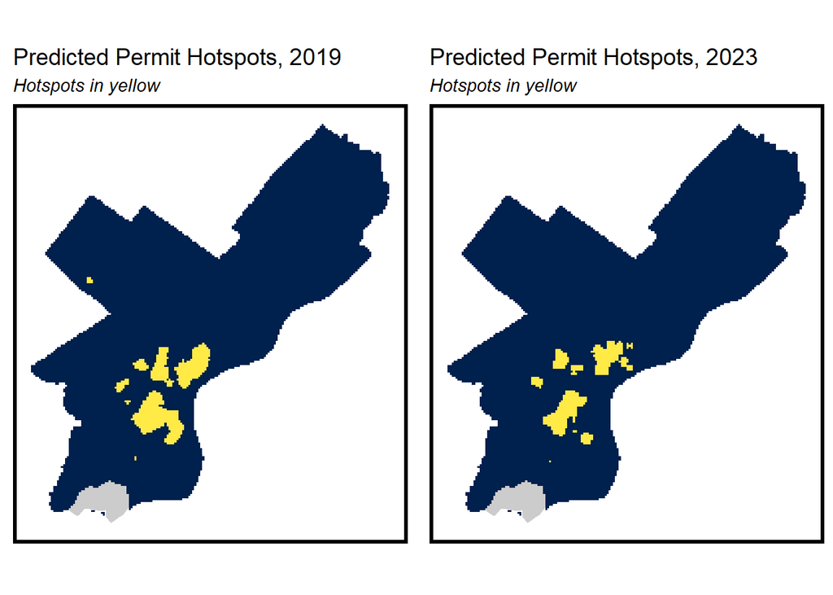

```r
grid.arrange(nrow=1,
ggplot() +
      geom_sf(data = nhoods, color = "transparent", fill = "gray80") +
      geom_sf(data = filter(final_predict.localMorans.Permit,
                            Variable == "Significant_Hotspots"),
              aes(fill = Value), colour=NA) +
      scale_fill_viridis(option = "E", name="") +
      labs(title="Predicted Permit Hotspots, 2019",
           subtitle="Hotspots in yellow") +
      mapTheme(title_size = 14) + theme(legend.position="none")
,
ggplot() +
      geom_sf(data = nhoods, color = "transparent", fill = "gray80") +
      geom_sf(data = filter(final_predict.localMorans.Permit_2122,
                            Variable == "Significant_Hotspots"),
              aes(fill = Value), colour=NA) +
      scale_fill_viridis(option = "E", name="") +
      labs(title="Predicted Permit Hotspots, 2023",
           subtitle="Hotspots in yellow") +
      mapTheme(title_size = 14) + theme(legend.position="none")
)
```

# 4 Discussion and Conclusion

Change is as real as life itself. When we travel around a city, we can see development happening in some places more than others, but you can organize action based on the eye test alone. Development is a process of change that shapes the built environment, alters the fabric of the city, and it functions as a vehicle for capital. Today, when people think about development they imagine gentrification. In this way, development has earned a negative connotation and communities fight to curb its forces. But we argue that development is a natural process of the city’s life and we should work with it rather than limit it totally or allow it to work freely.

To do this, we must develop a model that help us identify where development is happening in the city. We used OpenDataPhilly to obtain our initial permit data from 2009-2023. We defined development hotspots as areas where there were high rates of permits related to costly and large scale types of work. These hotspots reflect where investors were willing to inject their capital due to existing market forces. In doing so, they may alter the characteristics of the neighborhood and local population. We tried to capture these relationships in our prediction model through the use of changes in Philadelphia at the census block group level between 2013-2019 as indicators.

We find great value in the ability to determine development hotspots, so we wanted to know how many years worth of permits we needed in order to produce accurate predictions. To do this, we constructed and compared two models – a long-term Poisson regression model and a short-term one – to predict the total permit counts of individual fishnet cells. We used local Moran’s I to turn that data into a map of statistically significant hotspots. We ran diagnostic tests on our errors for accuracy and generalizability. The models generalize across incomes according to our results, but it is important to test more contexts in future development in order to verify how robust the model is. We were satisfied with the performance of our model but acknowledge that it could be more accurate with more data and further feature engineering to produce different predictor variables. However, the quantities of our errors are small and each model produces spatially defined hotspots that are easy to visualize and communicate.

We discovered that with just a few years worth of permit data, and engineered features related to socio-demographic changes, we could identify the city’s permit hotspots. Our analysis provides a statistically significant basis for the definition of areas in a city experiencing high rates of development. With this information we can pitch a targeted neighborhood-wide rezoning initiative in the predicted hotspots. We could wrangle development and with the stroke of a pen provide more affordable units, specify the size of businesses operating in the neighborhood, upzone, and overall make it easier to build. Ultimately, more creative ideas can emerge as they will be neighborhood-specific.

Our analysis in this project confirms what one can see on the ground in the permit hotspot areas. Because a sufficiently accurate model can be produced with only a couple of years of permit data, communities have an incentive to invest in advocating for their governments to document permit application in publicly available and easy-to-analyze formats. It would be easy to perform the analysis and identify statistically significant development hotspots. Moreover, from the perspective of a speculator, you could identify areas that are on the verge of becoming hotter hotspots and get into the market early. In shifting the conversation to development rather than gentrification, and to neighborhood wide rezonings instead of stern NIMBYism, we can plan more carefully with the forces that are present with us as we shape neighborhoods.